# Lab 03 - Multiple Linear Regression, model assessment

# The data

Usiamo i dati di automobili visti nel lab precedente: leggiamo direttamente i dati usando il file in Moodle:

```r
autompg <- read.csv(file = "autompg.csv")
```

Abbiamo 7 variabili: una variabile risposta (`mpg`) e 6 predittori:

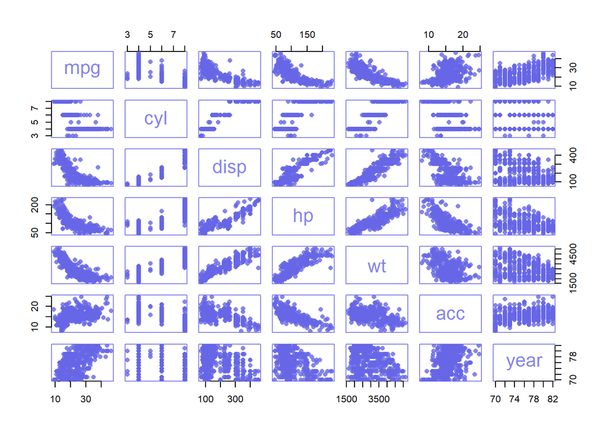

```r
## use rgb to define proportion of reg-green-blue in a color
## extra 4th argument is alpha - the transparency of the points
par(col= rgb(0.4,0.4,0.9,0.8),pch=16)
plot(autompg)
```

Presi individualemente alcuni predittori sembrano essere più o meno correlati con la variabile risposta e cio’ risulta in una predizione che non tiene conto di una corretta valutazione dell’incertezza.

```r
signif(cor(autompg),3)
```

```
##         mpg    cyl   disp     hp     wt    acc   year
## mpg   1.000 -0.777 -0.805 -0.778 -0.832  0.426  0.579
## cyl  -0.777  1.000  0.951  0.843  0.897 -0.508 -0.342
## disp -0.805  0.951  1.000  0.897  0.933 -0.546 -0.368
## hp   -0.778  0.843  0.897  1.000  0.864 -0.692 -0.415
## wt   -0.832  0.897  0.933  0.864  1.000 -0.419 -0.306
## acc   0.426 -0.508 -0.546 -0.692 -0.419  1.000  0.295
## year  0.579 -0.342 -0.368 -0.415 -0.306  0.295  1.000
```

Dovremo individuare un sottoinsieme di predittori utili a costruire un modello predittivo per `mpg` (vediamo inoltre che i predittori sono anche correlati tra loro).

# Specificazione del modello

Specifichiamo un modello con due predittori `hp` e `year`:

$$Y_i = \beta_0 + \beta_{hp} \text{hp}_{i} + \beta_{year} \text{year}_{i}
+ \epsilon_i, \qquad i = 1, 2, \ldots, n$$
con $\varepsilon_i \sim \mathcal{N}(0, \sigma^2)$ (errori indipendenti).

# Significatvita’ del modello

La prima domanda a cui vogliamo dare risposta e’: questo modello e’ significativo?

Dobbiamo testare che il modello sia significativo contro il modello nullo.

Formalmente dovremo dire se possiamo rifiutare l’ipotesi nulla, ad un livello di significativita’ del 5%, che i coefficienti del modello siano pari a 0.

```r
# Full model or alternative model
fit1 <- lm(mpg~hp+year, data = autompg)
# Null model
fit_null <- lm(mpg~1, data = autompg)
```

```r
summary(fit1)
```

```
##
## Call:
## lm(formula = mpg ~ hp + year, data = autompg)
##
## Residuals:
##      Min       1Q   Median       3Q      Max
## -12.0794  -3.0980  -0.4271   2.6023  15.3045
##
## Coefficients:
##               Estimate Std. Error t value Pr(>|t|)
## (Intercept) -12.859591   5.379128  -2.391   0.0173 *
## hp           -0.131650   0.006356 -20.714   <2e-16 ***
## year          0.658903   0.066680   9.882   <2e-16 ***
## ---
## Signif. codes:  0 '***' 0.001 '**' 0.01 '*' 0.05 '.' 0.1 ' ' 1
##
## Residual standard error: 4.398 on 387 degrees of freedom
## Multiple R-squared:  0.685,  Adjusted R-squared:  0.6833
## F-statistic: 420.7 on 2 and 387 DF,  p-value: < 2.2e-16
```

$$H_0: \beta_{hp} = \beta_{year} =
0$$
Quello che calcoliamo e’la statistica F, ovvero data $H_{0}$, quanto sarebbe possibile aver trovato una $SS_{RES}$ pari a quella fornita da $H_{1}$.

Alternativamente possiamo trovarla con un ANOVA del modello piu’ semplice contro quello piu’ complesso.

```r
anova(fit_null, fit1)
```

```
## Analysis of Variance Table
##
## Model 1: mpg ~ 1
## Model 2: mpg ~ hp + year
##   Res.Df     RSS Df Sum of Sq      F    Pr(>F)
## 1    389 23761.7
## 2    387  7485.8  2     16276 420.71 < 2.2e-16 ***
## ---
## Signif. codes:  0 '***' 0.001 '**' 0.01 '*' 0.05 '.' 0.1 ' ' 1
```

Da dove viene questo risultato? Noi valutiamo la misura di bonta’ d’adattamento dei modelli, la $SS_{RES}$, la porzione di variabilita’ spiegata dal modello.

Nel modello nullo, la stima e’ costante (si usa uno scalare per stimare y), questo porta ad una minore variabilita’ spiegata dal modello nullo contro una grande variabilita’ non spiegata affatto. Da qui notiamo che la `RSS` della riga 1, ovvero del modello nullo, e’ molto piu’ grande di quella della riga 2.

In poche parole, e’ evidente che il modello nullo sia meno efficiente nella spiegazione della variabilita’, anche perche’ la F-statistic e’ molto grande ed il p-value e’ estremamente piccolo!

Il calcolo sottostante e’ il seguente:

$$F = \frac{(SS_{RES}(H_{0}) -
SS_{RES}(H_{A}))/(p-q)}{SS_{RES}(H_{A})/(n-p)} = \frac
{\sum_{i=1}^{n}(\hat{y_{A,i}}-\hat{y_{0,i}})^{2}/(p-q)}{\sum_{i=1}^{n}(y_{i}-\hat{y_{A,i}})^2/(n-p)}
\thicksim F_{p-q, n-p}$$

Dove i gradi di liberta’ pesano sia il nominatore che il denominatore, ed il denominatore ha funzione di standardizzazione.

```r
# Manually this is what R does when computing the F statistics

# 1. Computes the RSS
RSS_h0 <- sum(residuals(fit_null)^2)
RSS_h1 <- sum(residuals(fit1)^2)

c(RSS_h0, RSS_h1)
```

```
## [1] 23761.672  7485.791
```

```r
# RSS_h0 - RSS_h1
RSS_diff <- sum(residuals(fit_null)^2) - sum(residuals(fit1)^2)
# Which is equal to the difference of the estimated values
# of the two models
est_diff <- sum((fitted(fit_null)-fitted(fit1))^2)

c(RSS_diff, est_diff)
```

```
## [1] 16275.88 16275.88
```

Se non ci fosse molta differenza tra i due modelli, queste somme sarebbero molto piccole e H1 non sarebbe molto significativo.

```r
# F statistic

# It explains how much more complex the model is with respect to H0
df_res_diff <- fit_null$df.residual - fit1$df.residual
# Above the fraction we find
num <- RSS_diff/df_res_diff
# Below the fraction we find
den <- RSS_h1/fit1$df.residual

# F statistic
fobs1 <- num/den

c(anova(fit_null, fit1)$F[2], fobs1)
```

```
## [1] 420.7148 420.7148
```

Calcoliamo ora il p-value, che e’ il valore

```r
# pvalue
pf(fobs1, df1 = df_res_diff,
   df2 = fit1$df.residual,
   lower.tail = FALSE)
```

```
## [1] 8.566348e-98
```

```r
# It is so small that we get 0
1-pf(fobs1, df1 = (fit_null$df.residual - fit1$df.residual),
   df2 = fit1$df.residual)
```

```
## [1] 0
```

L’alternativa e’ di confrontare fobs con fcrit specificando il livello di significativita’

```r
# 2%, so what is the quantile that leave 98% of the probability to the left
q<- qf(.98, df1 = df_res_diff,
   df2 = fit1$df.residual)
q
```

```
## [1] 3.951836
```

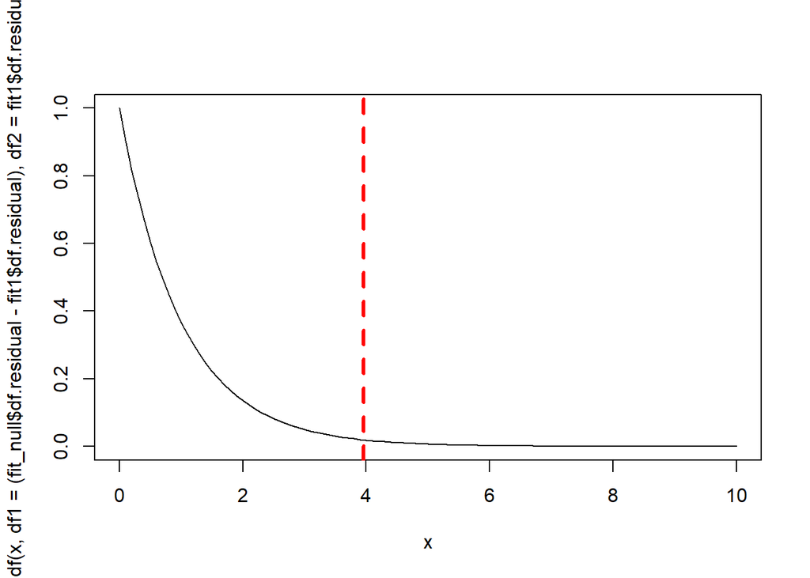

```r
curve(df(x,df1 = (fit_null$df.residual - fit1$df.residual),
   df2 = fit1$df.residual), from = 0, to = 10)
abline(v=q, col= "red", lwd = 3, lty =2)
#Too big to appear
points(fobs1, 0 , col = 2, pch = 4)
```

Abbiamo una fortissima evidenza che i nostri due parametri beta siano diversi da 0. Infatti:

```r
summary(fit1)$fstatistic
```

```
##    value    numdf    dendf
## 420.7148   2.0000 387.0000
```

# Nested Models

Come possiamo confrontare due modelli che sono annidati?

```r
fit_base <- lm(mpg~wt+year, data = autompg)

# lm(target ~ ., data = ..) includes all features
fit_all <- lm(mpg~., data = autompg)

summary(fit_all)
```

```
##
## Call:
## lm(formula = mpg ~ ., data = autompg)
##
## Residuals:
##     Min      1Q  Median      3Q     Max
## -8.7162 -2.3918 -0.0473  2.0381 14.3386
##
## Coefficients:
##               Estimate Std. Error t value Pr(>|t|)
## (Intercept) -1.470e+01  4.772e+00  -3.081  0.00221 **
## cyl         -3.534e-01  3.335e-01  -1.060  0.28993
## disp         8.028e-03  7.376e-03   1.088  0.27709
## hp          -6.625e-04  1.387e-02  -0.048  0.96193
## wt          -6.791e-03  6.709e-04 -10.121  < 2e-16 ***
## acc          8.053e-02  1.026e-01   0.785  0.43297
## year         7.577e-01  5.289e-02  14.328  < 2e-16 ***
## ---
## Signif. codes:  0 '***' 0.001 '**' 0.01 '*' 0.05 '.' 0.1 ' ' 1
##
## Residual standard error: 3.439 on 383 degrees of freedom
## Multiple R-squared:  0.8093, Adjusted R-squared:  0.8064
## F-statistic:   271 on 6 and 383 DF,  p-value: < 2.2e-16
```

Il p-value e’ molto significativo

Questa diminuzione della stima di $\sigma^{2}$, ovvero $SS_{RES}$, e’ diversa dal punto di vista statistico oppure stiamo stimando una porzione simile di variabilita’? Bisogna ricordare che il modello piu’ complesso implica maggiore difficolta’ con la predizione.

```r
# The SS Res diminishes
# 26 points more, but is it worth the complexity?
c(sum(residuals(fit_base)^2), sum(residuals(fit_all)^2))
```

```
## [1] 4556.646 4530.466
```

Inoltre, il modello potrebbe essere sovraparametrizzato dal momento che molte variabili incluse nel secondo modello, non sono molto significative. Ad esempio `hp` che prima sembrava essere una variabile interessante, ricopre ora un ruolo apparentemente marginale.

Dunque, ne vale la pena?

## Confidence Intervals

Creiamo un dataframe ad hoc per degli intervalli di confidenza e ne guardiamo l’ampiezza.

```r
# Create new dataframe, where for each of the predictors of mpg
# we take some data that is at extreme quantiles and at the median
# We apply a vectorized function
nd <- data.frame(apply(autompg, 2, quantile, c(0.1, 0.5, 0.9)))

# Confidence intervals for the two models
(ci_all <- predict(fit_all , newdata = nd, interval = "conf"))
```

```
##          fit      lwr      upr
## 10% 25.81569 24.52220 27.10918
## 50% 24.77921 24.06877 25.48964
## 90% 19.01879 17.50895 20.52863
```

```r
(ci_base <- predict(fit_base , newdata = nd, interval = "conf"))
```

```
##          fit      lwr      upr
## 10% 26.22181 25.41514 27.02848
## 50% 24.57827 24.22949 24.92705
## 90% 18.64130 17.73176 19.55084
```

```r
ci_all[,3]- ci_all[,2]
```

```
##      10%      50%      90%
## 2.586979 1.420871 3.019683
```

```r
ci_base[,3]- ci_base[,2]
```

```
##       10%       50%       90%
## 1.6133375 0.6975514 1.8190836
```

Si nota che gli intervalli di `ci_base` sono piu’ stretti, R-squared e’ piu’ piccolo e che ha meno variabilita’nell’intervallo di stima che teniamo.

Questo e’ dovuto al fatto che nel modello sovraparametrizzato seguiamo delle caratteristiche peculiari dei dati che non necessariamente sono generalizzabili. Nel momento di valutazione di valutazione dell’errore di predizione, questo e’ ben piu’ grande!

Anche se qui e’ effettivamente molto semplice scovare questi dettagli, non e’ sempre cosi’.

## ANOVA

Andiamo quindi a confrontare se il miglioramento nell $R^{2}$ dei $SS_{RES}$ e’ significativo.

```r
anova(fit_base, fit_all)
```

```
## Analysis of Variance Table
##
## Model 1: mpg ~ wt + year
## Model 2: mpg ~ cyl + disp + hp + wt + acc + year
##   Res.Df    RSS Df Sum of Sq      F Pr(>F)
## 1    387 4556.6
## 2    383 4530.5  4     26.18 0.5533 0.6967
```

We can see that the F is not that big, nor the p-value is small.

```r
# By hand F-statistic verification
num <- (sum(residuals(fit_base)^2) - sum(residuals(fit_all)^2))/(fit_base$df.residual - fit_all$df.residual)
den <- sum(residuals(fit_all)^2)/fit_all$df.residual
fobs <- num/den

# p-value
p_val <- pf(fobs, lower.tail = FALSE, df1 = (fit_base$df.residual - fit_all$df.residual),
   df2 = fit_all$df.residual)

c(fobs, p_val)
```

```
## [1] 0.5533023 0.6967249
```

```r
c(anova(fit_base, fit_all)$F[2], anova(fit_base, fit_all)$Pr[2])
```

```
## [1] 0.5533023 0.6967249
```

```r
# reject H0 if fobs > fcri
k <- qf(.98 , df1 = (fit_base$df.residual - fit_all$df.residual),
   df2 = fit_all$df.residual)
k
```

```
## [1] 2.954046
```

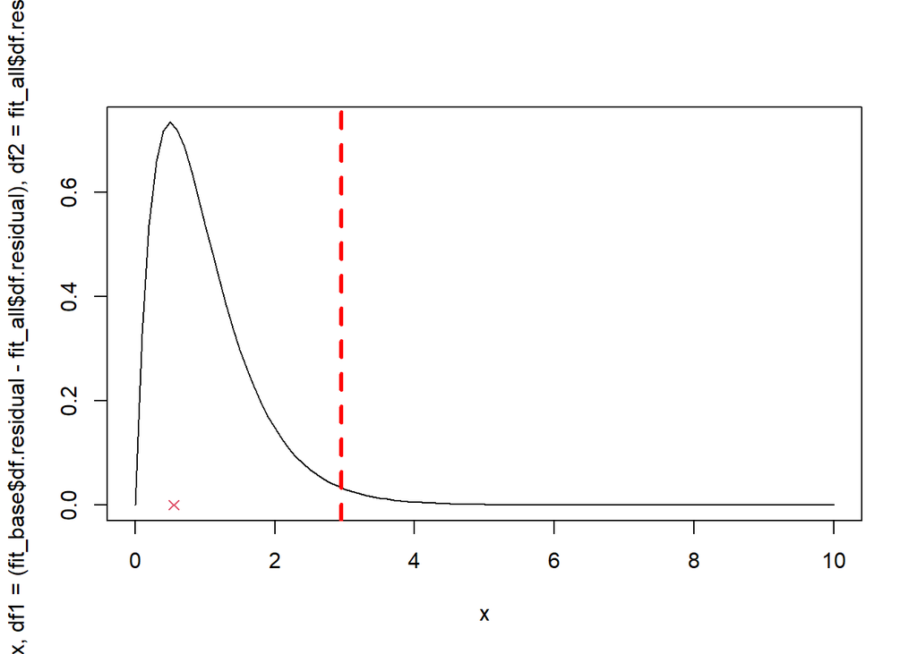

```r
curve(df(x, df1 = (fit_base$df.residual - fit_all$df.residual),
   df2 = fit_all$df.residual), from = 0, to = 10)
abline(v=k, col= "red", lwd = 3, lty =2)
points(fobs, 0 , col = 2, pch = 4)
```

La statistica test non e’ nella coda della distribuzione, quindi vi e’ poca evidenza contro l’ipotesi nulla. Ci conviene mantenere il modello piu’ parsimonioso e senza parametri che forniscano rumore.

# Bontà di adattemnto: confornto tra modelli non annidati

Ora, dato che abbiamo modelli non annidati dobbiamo usare altre misure:

1. $Adjusted R^{2}$
2. ICs
   - AIC
   - BIC

## Adjusted R-squared

$$Adjusted \; R^{2} = 1 -
\frac{SS_{RES}/(n-p-1)}{SS_{TOT}/(n-1)}$$

```r
# From model: r-square vs adj-r-square
c("R-square", summary(fit_base)$r.square)
```

```
## [1] "R-square"          "0.808235479015204"
```

```r
c("Adjusted-r-squared", summary(fit_base)$adj.r.square)
```

```
## [1] "Adjusted-r-squared" "0.807244447899003"
```

```r
# By hand
c(1-sum(residuals(fit_base)^2)/(sum((autompg$mpg - mean(autompg$mpg))^2)), 1-(sum(residuals(fit_base)^2)/fit_base$df.residual)/(sum((autompg$mpg - mean(autompg$mpg))^2)/fit_null$df.residual))
```

```
## [1] 0.8082355 0.8072444
```

```r
# Adjusted R Square for Fit
c( "Adjusted R Square for fit1", summary(fit1)$adj.r.square)
```

```
## [1] "Adjusted R Square for fit1" "0.683335530249261"
```

```r
c( "Adjusted R Square for fit_base", summary(fit_base)$adj.r.square)
```

```
## [1] "Adjusted R Square for fit_base" "0.807244447899003"
```

```r
c( "Adjusted R Square for fit_all", summary(fit_all)$adj.r.square)
```

```
## [1] "Adjusted R Square for fit_all" "0.806350361529024"
```

## Criteri di informazione

### AIC

$$AIC(\mathcal{M}) = n * \log
MSS_{RES}(\mathcal{M}) + 2p(\mathcal{M})$$

```r
# Log Likelihood
logLik(fit_base)
```

```
## 'log Lik.' -1032.734 (df=4)
```

```r
logLik(fit_all)
```

```
## 'log Lik.' -1031.611 (df=8)
```

```r
# By hand the logLik
sum(dnorm(autompg$mpg, mean = fitted(fit_base),
           sd = summary(fit_base)$sigma, log = TRUE))
```

```
## [1] -1032.74
```

```r
# AIC
c(AIC(fit_base), AIC(fit_all))
```

```
## [1] 2073.468 2079.221
```

```r
# By Hand
c(-2*logLik(fit_base)+2*(length(coef(fit_base))+1), -2*logLik(fit_all)+2*(length(coef(fit_all))+1))
```

```
## [1] 2073.468 2079.221
```

Come vediamo, la differenza tra le logLik e’ molto piccola ed aggiungere i 4 parametri in piu’ non vale la candela.

Di default `AIC()` conta sigma come un parametro stimato, solo che l’ordine degli AIC non cambia!

### BIC

IC in cui la penalizzazione dei modelli complessi e’ piu’ ferrea.

$$BIC(\mathcal{M}) = n * \log
MSS_{RES}(\mathcal{M}) + \log (n)p(\mathcal{M})$$

```r
# BIC
c(BIC(fit_base), BIC(fit_all))
```

```
## [1] 2089.333 2110.950
```

```r
# By hand
c(-2*logLik(fit_base)+log(nrow(autompg))*(length(coef(fit_base))+1), -2*logLik(fit_all)+log(nrow(autompg))*(length(coef(fit_all))+1))
```

```
## [1] 2089.333 2110.950
```

```r
# Which is the same as the AIC with log(n)
AIC(fit_base, k = log(nrow(autompg)))
```

```
## [1] 2089.333
```

Ed ancora, i pochi punti in piu’ non sono sufficienti ad aumentare.

# Verificare la teoria tramite simulazione

Come interpretare l’effetto che hanno i singoli $\beta_{j}$ sulla nostra stima, sulla variabilita’? Perche’ avere varabilita’ in eccesso non e’ sempre una buona idea?Cosa vuol dire che una stima del modello non e’ significativa? Come verificarlo?

Cerchiamo di rispondere a queste domande, verificando la teoria: 1. E’vero che la distribuzione campionaria delle stime di beta, $\hat{\beta}$ si comporta cosi’? 2. La differenza tra una variabile significativa ed una non significativa nel modello, ovvero quando una spiega qualcosa ma l’ altra no.

```r
# We fix the Xs and their distribution
# We simulate them so that they have similar distribution to fit_base

# The X matrix is the design matrix, extracted from fit_base
# We then fix the coefficients and the distribution
X <- model.matrix(fit_base)
# Intercept, x1, x2 are just casual fixed var
colnames(X) <- c("Int", "x1","x2")
sigma_true <- 3.4
beta_true <- c(-14, -0.006, .74)
n <- nrow(X)

# set.seed(8686)

# If we had a different sample of cars, we could have this kind of relation
y_alternative <- X %*% beta_true +  rnorm(n, 0, sigma_true)
# If we observed a different sample and a different dataframe
autodf_alterntive <- data.frame(y = y_alternative, X[,-1])
# Which would result in a model like this
lm(y~x1+x2, data = autodf_alterntive)
```

```
##
## Call:
## lm(formula = y ~ x1 + x2, data = autodf_alterntive)
##
## Coefficients:
## (Intercept)           x1           x2
##  -11.958062    -0.006334     0.729753
```

Generando e stimando piu’ volte, campioni con basi simili, possiamo avere una media di come si comporta il modello e quindi i coefficienti calcolati. Infatti, se in piu’ “mondi alternativi” la nostra stima vanta sempre della stessa non-distorsione, e dello stesso comportamento descritto (varianza omoschedastica …), sara’una buona stima

Ora vediamo di scrivere una funzione che automatizzi questo processo.

```r
# The matrix model, the true values of beta, and true value of SD
generate_and_estimate <- function(X, truebeta, truesigma){
  n <- nrow(X)
  y_alternative <- X %*% truebeta+  rnorm(n, 0, truesigma)
  autodf_alterntive <- data.frame(y = y_alternative, X[,-1])
  estimate <- coef(lm(y~x1+x2, data = autodf_alterntive))
  estimate
}

# Replicate it 500 times
generate_and_estimate(X = X, truebeta = beta_true, truesigma = sigma_true)
```

```
##  (Intercept)           x1           x2
## -9.341338643 -0.006187323  0.680800997
```

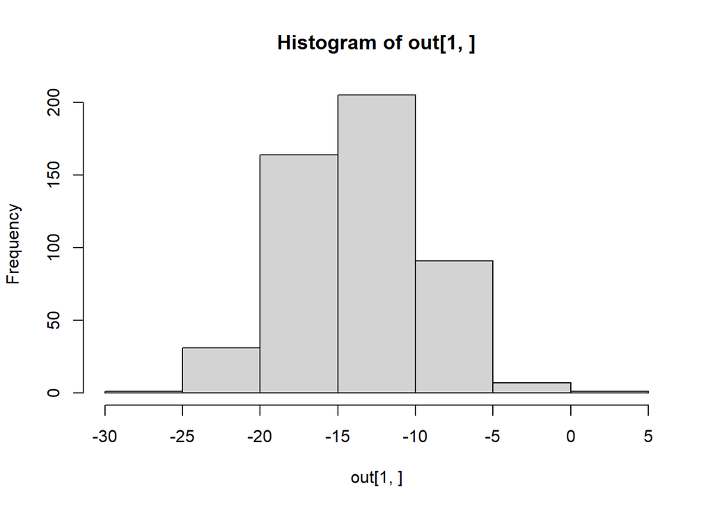

```r
out <- replicate(n = 500, generate_and_estimate(X = X, truebeta = beta_true, truesigma = sigma_true))
hist(out[1,])
```

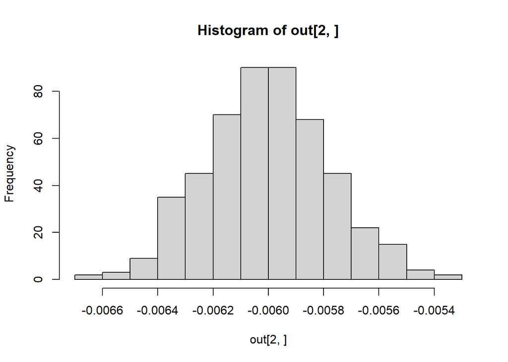

```r
hist(out[2,])
```

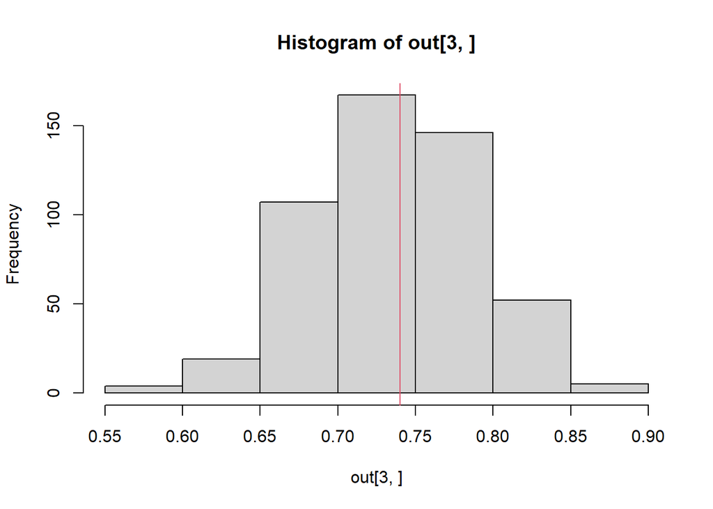

```r
hist(out[3,]); abline(v = beta_true[3], col = 2)
```

```r
mean(out[3,])
```

```
## [1] 0.7365606
```

```r
# This matrix is derived from the 500 alternative samples
cov(t(out))
```

```
##              (Intercept)            x1            x2
## (Intercept) 17.279593235 -3.867360e-04 -2.108732e-01
## x1          -0.000386736  4.841162e-08  3.162102e-06
## x2          -0.210873161  3.162102e-06  2.640018e-03
```

```r
# The true vcov matrix is
sigma_true^2 * solve(t(X) %*%X)
```

```
##               Int            x1            x2
## Int 15.8930811700 -3.792233e-04 -1.939760e-01
## x1  -0.0003792233  4.532063e-08  3.214476e-06
## x2  -0.1939759626  3.214476e-06  2.427733e-03
```